# Анализ научных публикаций на тему ‘Искусственный интеллект в образовании’

Askhat Makhmetov

4.08.2025

## Введение

Этот отчет представляет собой комплексный анализ текстовых данных из научных публикаций, посвященных применению искусственного интеллекта (ИИ) в образовании. Данные были выгружены из базы Scopus. Анализ включает в себя:

1. **Подготовку данных**: загрузку, очистку и фильтрацию.
2. **Предобработку текста**: лемматизацию и удаление стоп-слов.
3. **Частотный анализ**: выявление наиболее популярных N-граммов и ключевых слов с помощью TF-IDF.
4. **Тематическое моделирование (LDA)**: определение основных тематических кластеров в корпусе текстов.
5. **Анализ тональности**: оценка общего настроения публикаций.

### Шаг 0: Установка и загрузка библиотек

В этом блоке мы загружаем все необходимые библиотеки для анализа. Если какая-либо из них не установлена, необходимо раскомментировать (убрать `#`) и выполнить соответствующую строку `install.packages()`.

```r
# Если какая-то из библиотек не установлена, раскомментируйте и выполните нужную строку
# install.packages("tidyverse")
# install.packages("tidytext")
# install.packages("udpipe")
# install.packages("topicmodels")
# install.packages("wordcloud2")
# install.packages("stopwords")

library(tidyverse)    # Для манипуляций с данными и визуализации
library(tidytext)     # Основной инструмент для текстового анализа
library(udpipe)       # Для качественной лемматизации
library(topicmodels)  # Для тематического моделирования (LDA)
library(wordcloud2)   # Для создания облаков слов
library(stopwords)    # Для расширенных списков стоп-слов
```

### Шаг 1: Загрузка и первичная подготовка данных

Загружаем данные из CSV-файла, выгруженного из Scopus. Затем отбираем только англоязычные статьи, у которых есть аннотация (Abstract). Объединяем заголовок и аннотацию в единое текстовое поле `text`.

**Важно:** Убедитесь, что путь к файлу `file_path` указан корректно для вашей системы.

```r
# Указываем путь к вашему файлу.
file_path <- "/Users/Askhat/Desktop/KSL/NLP/Final/AI_in_Edu.csv"

# Загружаем CSV файл
scopus_data <- readr::read_csv(file_path, col_types = cols(.default = "c"))

# Подготовка данных с фильтрацией по полному названию колонки
ai_edu_text <- scopus_data %>%
  # Фильтруем по колонке с пробелами, используя обратные кавычки
  filter(`Language of Original Document` == "English") %>%
  # Выбираем нужные колонки и создаем единое текстовое поле
  select(ID = EID, Title, Abstract, Year) %>%
  mutate(text = paste(Title, Abstract, sep = ". ")) %>%
  # Убираем строки без аннотации
  filter(!is.na(Abstract) & Abstract != "") %>%
  # Пересоздаем ID для уникальности
  mutate(ID = row_number())

cat("--- 1. Данные загружены и подготовлены ---\n")
```

```
## --- 1. Данные загружены и подготовлены ---
```

```r
cat("Всего для анализа отобрано:", nrow(ai_edu_text), "публикаций.\n")
```

```
## Всего для анализа отобрано: 10587 публикаций.
```

### Шаг 2: Предобработка текста

Этот этап является ключевым для качественного анализа. Он состоит из нескольких подзадач.

#### 2.1 Лемматизация

Лемматизация — это процесс приведения слова к его базовой, словарной форме (лемме). Мы используем модель `udpipe` для английского языка, так как она обеспечивает высокое качество лемматизации.

**Примечание:** Процесс лемматизации может занять много времени. В предоставленном коде этот шаг закомментирован, и вместо него загружается уже обработанный файл `lemmatized_tokens_output.csv`. Если вы запускаете код впервые, вам нужно будет выполнить лемматизацию.

```r
# --- Код для выполнения лемматизации (закомментирован) ---
# При первом запуске модель скачается из интернета.
# udpipe_download_model(language = "english-ewt")
# ud_model <- udpipe_load_model(file = udpipe_download_model(language = "english-ewt")$file_model)

# Применяем модель для аннотирования текста.
# lemmatized_tokens <- udpipe_annotate(ud_model, x = ai_edu_text$text, doc_id = ai_edu_text$ID) %>%
#   as_tibble()
#
# # Сохраняем результат, чтобы не повторять процесс
# readr::write_csv(lemmatized_tokens, "lemmatized_tokens_output.csv")


# --- Загрузка готового файла с леммами ---
# Указываем путь к вашему файлу с леммами
file_path_lemmas <- "/Users/Askhat/Desktop/KSL/NLP/Final/lemmatized_tokens_output.csv"

# Читаем CSV файл
lemmatized_tokens <- read_csv(file_path_lemmas)

cat("Данные с леммами успешно загружены.\n")
```

```
## Данные с леммами успешно загружены.
```

```r
head(lemmatized_tokens)
```

```
## # A tibble: 6 × 14
##   doc_id paragraph_id sentence_id sentence      token_id token lemma upos  xpos
##    <dbl>        <dbl>       <dbl> <chr>            <dbl> <chr> <chr> <chr> <chr>
## 1      1            1           1 Quality asse…        1 Qual… qual… NOUN  NN
## 2      1            1           1 Quality asse…        2 asse… asse… NOUN  NN
## 3      1            1           1 Quality asse…        3 of    of    ADP   IN
## 4      1            1           1 Quality asse…        4 GPT   GPT   PROPN NNP
## 5      1            1           1 Quality asse…        5 -     -     PUNCT HYPH
## 6      1            1           1 Quality asse…        6 3.5   3.5   NUM   CD
## # ℹ 5 more variables: feats <chr>, head_token_id <dbl>, dep_rel <chr>,
## #   deps <lgl>, misc <chr>
```

#### 2.2 Создание объединенного списка стоп-слов

Стандартного списка стоп-слов часто недостаточно для анализа научной литературы. Мы создаем собственный расширенный список, который включает общие английские стоп-слова и термины, специфичные для научных статей (например, “study”, “result”, “doi” и т.д.).

```r
# 1. Получаем стандартный список английских стоп-слов
english_stop_words <- stopwords("en")

# 2. Создаем вектор с кастомными стоп-словами
custom_stop_words <- c("doi", "na", "j", "et", "al", "figure", "table", "abstract",
                       "introduction", "method", "result", "conclusion", "discussion",
                       "study", "paper", "research", "author", "article", "purpose",
                       "finding", "implication", "elsevier", "springer", "ieee", "copyright")

# 3. Объединяем оба списка и убираем дубликаты
all_stop_words_vector <- unique(c(english_stop_words, custom_stop_words))

# 4. Преобразуем вектор в таблицу для использования с `anti_join`
all_stop_words_df <- tibble(word = all_stop_words_vector)

cat("Объединенный список стоп-слов создан. Всего слов:", nrow(all_stop_words_df), "\n")
```

```
## Объединенный список стоп-слов создан. Всего слов: 200
```

#### 2.3 Финальная очистка лемм

Теперь мы очищаем наши лемматизированные токены: 1. Оставляем только значащие части речи: существительные (`NOUN`), глаголы (`VERB`), прилагательные (`ADJ`) и имена собственные (`PROPN`). 2. Удаляем все слова из нашего объединенного списка стоп-слов. 3. Убираем слишком короткие слова (менее 3 букв).

```r
lemmas_clean <- lemmatized_tokens %>%
  # ШАГ 1: Фильтруем по части речи
  filter(upos %in% c("NOUN", "VERB", "ADJ", "PROPN")) %>%

  # ШАГ 2: Выбираем только нужные колонки
  select(doc_id, lemma) %>%
  rename(word = lemma) %>%

  # ШАГ 3: Убираем стоп-слова из нашего объединенного списка
  anti_join(all_stop_words_df, by = "word") %>%

  # ШАГ 4: Убираем короткие слова и остатки мусора
  filter(nchar(word) > 2)

cat("--- 2. Предобработка завершена ---\n")
```

```
## --- 2. Предобработка завершена ---
```

```r
cat("Текст очищен от пунктуации, стоп-слов и коротких токенов.\n\n")
```

```
## Текст очищен от пунктуации, стоп-слов и коротких токенов.
```

```r
head(lemmas_clean)
```

```
## # A tibble: 6 × 2
##   doc_id word
##    <dbl> <chr>
## 1      1 quality
## 2      1 assessment
## 3      1 GPT
## 4      1 Gemini
## 5      1 pro
## 6      1 Sql
```

### Шаг 3: Частотный анализ

На этом этапе мы анализируем, какие слова и словосочетания встречаются в текстах чаще всего.

#### 3.1 Анализ N-граммов (биграммы и триграммы)

N-граммы — это последовательности из N слов. Биграммы (2 слова) и триграммы (3 слова) помогают понять контекст и выявить устойчивые словосочетания.

```r
# Анализ биграмм (пар слов)
bigrams <- ai_edu_text %>%
  unnest_tokens(bigram, text, token = "ngrams", n = 2) %>%
  separate(bigram, c("word1", "word2"), sep = " ") %>%
  filter(!word1 %in% all_stop_words_vector, !word2 %in% all_stop_words_vector) %>%
  unite(bigram, word1, word2, sep = " ") %>%
  count(bigram, sort = TRUE)

# Анализ триграмм (троек слов)
trigrams <- ai_edu_text %>%
  unnest_tokens(trigram, text, token = "ngrams", n = 3) %>%
  separate(trigram, c("word1", "word2", "word3"), sep = " ") %>%
  filter(!word1 %in% all_stop_words_vector, !word2 %in% all_stop_words_vector, !word3 %in% all_stop_words_vector) %>%
  unite(trigram, word1, word2, word3, sep = " ") %>%
  count(trigram, sort = TRUE)

# Вывод топ-15
cat("--- Топ-15 биграмм: ---\n")
```

```
## --- Топ-15 биграмм: ---
```

```r
print(head(bigrams, 15))
```

```
## # A tibble: 15 × 2
##    bigram                      n
##    <chr>                   <int>
##  1 artificial intelligence 11196
##  2 higher education         3790
##  3 intelligence ai          3634
##  4 generative ai            2342
##  5 ai tools                 1821
##  6 generative artificial    1340
##  7 ai literacy              1323
##  8 machine learning         1259
##  9 ai based                  945
## 10 university students       883
## 11 learning outcomes         874
## 12 ai technologies           858
## 13 critical thinking         856
## 14 medical education         835
## 15 large language            797
```

```r
cat("\n--- Топ-15 триграмм: ---\n")
```

```
##
## --- Топ-15 триграмм: ---
```

```r
print(head(trigrams, 15))
```

```
## # A tibble: 15 × 2
##    trigram                                n
##    <chr>                              <int>
##  1 artificial intelligence ai          3625
##  2 generative artificial intelligence  1339
##  3 large language models                639
##  4 higher education institutions        415
##  5 design methodology approach          401
##  6 pre service teachers                 375
##  7 artificial intelligence genai        365
##  8 structural equation modeling         305
##  9 semi structured interviews           299
## 10 systematic literature review         299
## 11 using artificial intelligence        285
## 12 natural language processing          281
## 13 language models llms                 270
## 14 covid 19 pandemic                    266
## 15 generative ai tools                  253
```

#### Визуализация топ-15 биграмм

График ниже наглядно показывает самые частые словосочетания из двух слов.

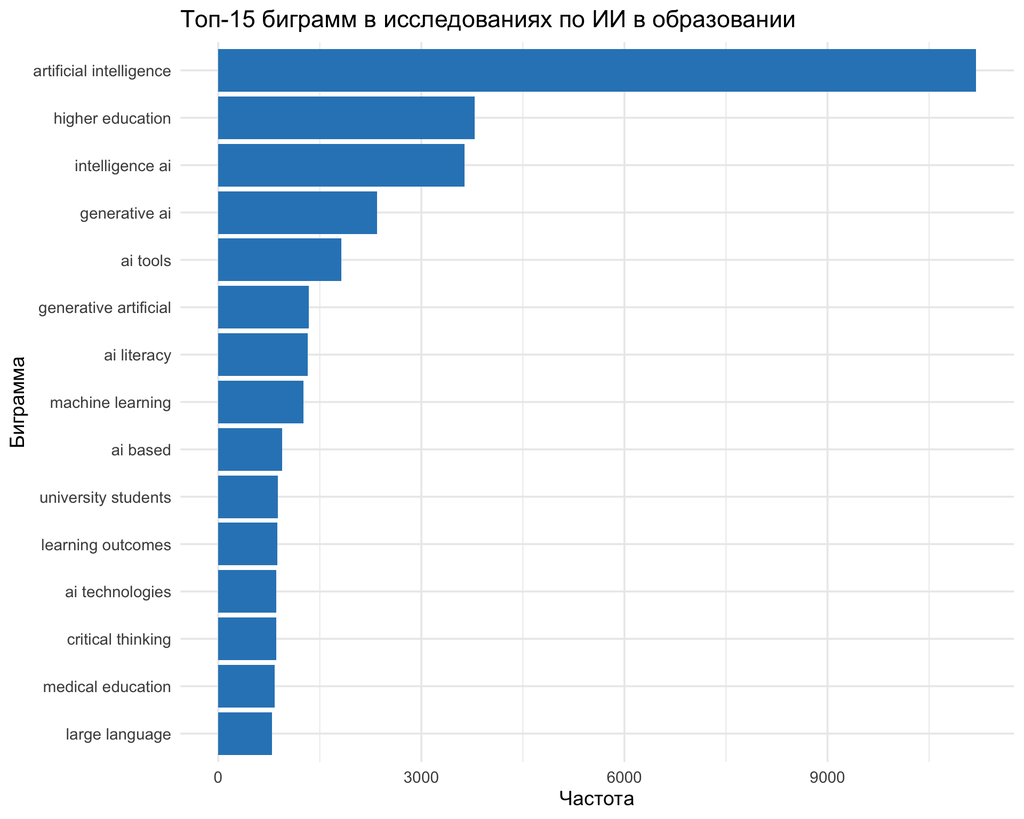

```r
bigrams %>%
  head(15) %>%
  ggplot(aes(x = reorder(bigram, n), y = n)) +
  geom_col(fill = "#2E86C1") +
  coord_flip() +
  labs(title = "Топ-15 биграмм в исследованиях по ИИ в образовании",
       x = "Биграмма", y = "Частота") +
  theme_minimal(base_size = 14)
```

#### 3.2 Анализ TF-IDF

**TF-IDF** (Term Frequency-Inverse Document Frequency) — это метрика, которая показывает важность слова в контексте документа (статьи). Слова, которые часто встречаются в одной статье, но редко во всех остальных, получают высокий балл TF-IDF и являются хорошими маркерами содержания этого документа.

```r
tf_idf <- lemmas_clean %>%
  count(doc_id, word, sort = TRUE) %>%
  bind_tf_idf(word, doc_id, n) %>%
  arrange(desc(tf_idf))

cat("\n--- Топ-15 слов по TF-IDF: ---\n")
```

```
##
## --- Топ-15 слов по TF-IDF: ---
```

```r
print(head(tf_idf, 15))
```

```
## # A tibble: 15 × 6
##    doc_id word                n    tf   idf tf_idf
##     <dbl> <chr>           <int> <dbl> <dbl>  <dbl>
##  1   8036 Laws                1 0.2    9.27   1.85
##  2   6385 futuristic          1 0.25   6.38   1.59
##  3   9246 avalanche           1 0.167  9.27   1.54
##  4  10423 Obscur              1 0.167  9.27   1.54
##  5  10442 prototypicality     1 0.167  9.27   1.54
##  6  10548 Microelectronic     1 0.167  9.27   1.54
##  7  10581 inf                27 0.267  5.74   1.53
##  8  10510 Sūtra               2 0.154  9.27   1.43
##  9   4834 discussions         1 0.2    6.96   1.39
## 10  10548 impaire             1 0.167  8.17   1.36
## 11   9694 Augmented           1 0.25   5.42   1.35
## 12   8968 editorial           1 0.25   5.34   1.33
## 13   7147 Jensen              1 0.143  9.27   1.32
## 14   7147 Kyle                1 0.143  9.27   1.32
## 15   2583 résumé             10 0.141  9.27   1.31
```

#### Визуализация топ-15 слов по TF-IDF

На графике представлены слова с самой высокой “уникальной важностью” во всем корпусе текстов.

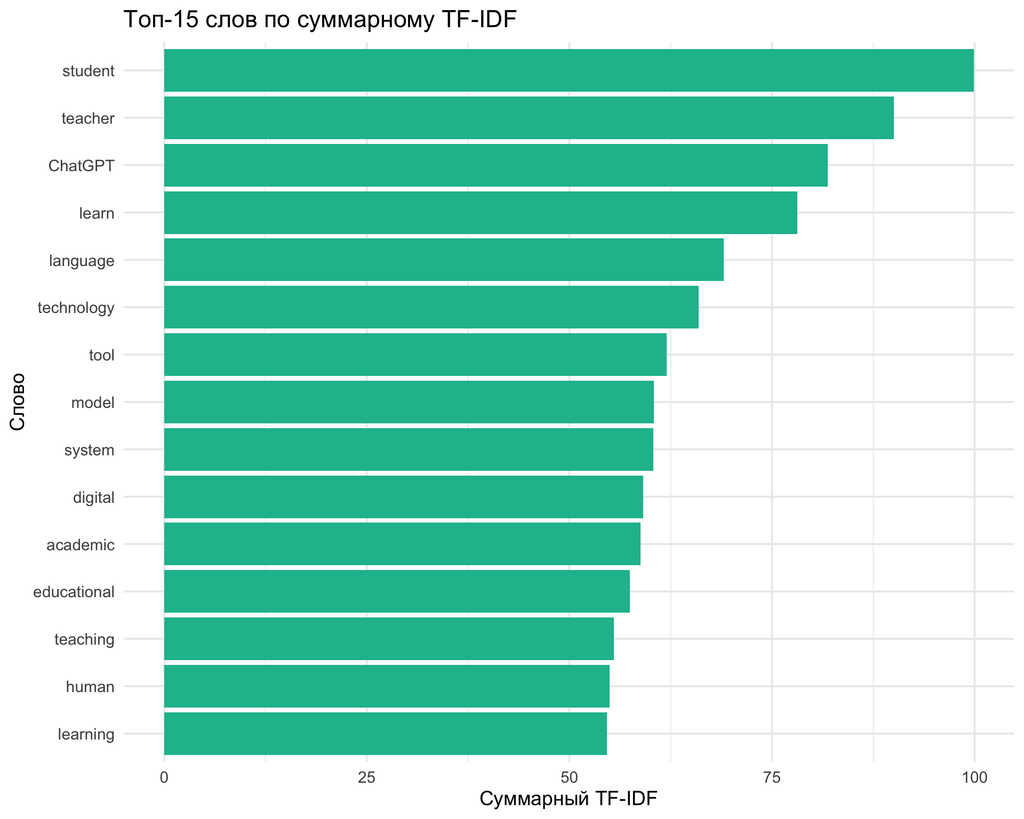

```r
tf_idf %>%
  group_by(word) %>%
  summarise(total_tf_idf = sum(tf_idf)) %>%
  arrange(desc(total_tf_idf)) %>%
  head(15) %>%
  ggplot(aes(x = reorder(word, total_tf_idf), y = total_tf_idf)) +
  geom_col(fill = "#1ABC9C") +
  coord_flip() +
  labs(title = "Топ-15 слов по суммарному TF-IDF", x = "Слово", y = "Суммарный TF-IDF") +
  theme_minimal(base_size = 14)
```

### Шаг 4: Тематическое моделирование (LDA)

Латентное размещение Дирихле (LDA) — это вероятностная модель, которая позволяет выявить “темы” (скрытые группы слов) в коллекции документов. Мы применим LDA, чтобы определить 6 основных исследовательских направлений в нашем наборе статей.

```r
# Создаем матрицу "документ-термин" (DTM)
dtm <- lemmas_clean %>%
  count(doc_id, word, sort = TRUE) %>%
  cast_dtm(doc_id, word, n)

# Запускаем LDA. k - это количество тем.
set.seed(123) # для воспроизводимости результатов
lda_model <- LDA(dtm, k = 6, control = list(seed = 123))

# Извлекаем результаты в "tidy" формате
lda_topics <- tidy(lda_model, matrix = "beta")

# Находим топ-10 слов для каждой темы
top_terms <- lda_topics %>%
  group_by(topic) %>%
  slice_max(beta, n = 10) %>%
  ungroup() %>%
  arrange(topic, -beta)

cat("\n--- Топ-10 слов для каждой из 6 тем (LDA): ---\n")
```

```
##
## --- Топ-10 слов для каждой из 6 тем (LDA): ---
```

```r
print(top_terms, n = 60)
```

```
## # A tibble: 60 × 3
##    topic term            beta
##    <int> <chr>          <dbl>
##  1     1 intelligence 0.0115
##  2     1 student      0.0115
##  3     1 tool         0.0112
##  4     1 learn        0.0105
##  5     1 use          0.0105
##  6     1 educational  0.0102
##  7     1 learning     0.00873
##  8     1 artificial   0.00786
##  9     1 ChatGPT      0.00768
## 10     1 language     0.00721
## 11     2 use          0.0164
## 12     2 student      0.0140
```

[output cut: 48 more lines]

#### Визуализация тем (LDA)

Каждая панель на графике ниже представляет одну из 6 тем. На ней показаны 10 самых вероятных слов для этой темы. Это позволяет нам интерпретировать и дать название каждой теме.

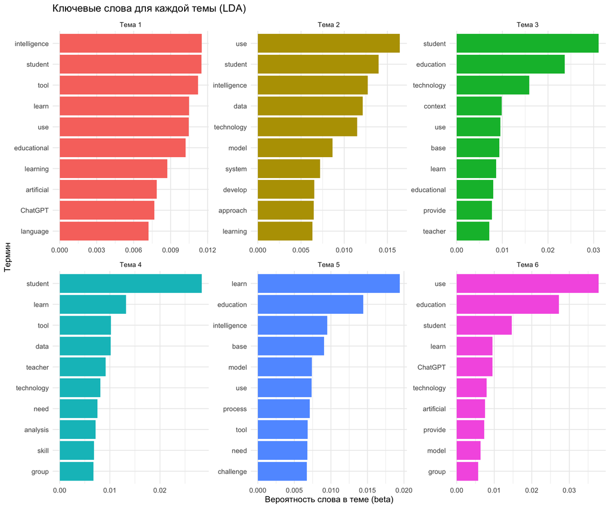

```r
top_terms %>%
  mutate(term = reorder_within(term, beta, topic)) %>%
  ggplot(aes(beta, term, fill = factor(topic))) +
  geom_col(show.legend = FALSE) +
  facet_wrap(~ paste("Тема", topic), scales = "free") +
  scale_y_reordered() +
  labs(title = "Ключевые слова для каждой темы (LDA)",
       x = "Вероятность слова в теме (beta)", y = "Термин") +
  theme_minimal(base_size = 12)
```

### Шаг 5: Анализ тональности (Сентимент-анализ)

Сентимент-анализ позволяет определить эмоциональную окраску текста. Мы используем словарь “bing”, который классифицирует слова как “positive” или “negative”. Это поможет понять общее настроение в обсуждаемой научной области.

```r
# Используем словарь "bing" для определения тональности
bing_sentiments <- get_sentiments("bing")

# Присоединяем словарь тональности к нашим леммам
sentiment_analysis <- lemmas_clean %>%
  inner_join(bing_sentiments, by = "word")

# Подсчитываем общее количество позитивных и негативных слов
sentiment_summary <- sentiment_analysis %>%
  count(sentiment)

cat("\n--- Общее распределение тональности: ---\n")
```

```
##
## --- Общее распределение тональности: ---
```

```r
print(sentiment_summary)
```

```
## # A tibble: 2 × 2
##   sentiment     n
##   <chr>     <int>
## 1 negative  32744
## 2 positive  94316
```

```r
# Находим топ-10 самых частых позитивных и негативных слов
top_sentiment_words <- sentiment_analysis %>%
  count(word, sentiment, sort = TRUE) %>%
  group_by(sentiment) %>%
  slice_max(n, n = 10) %>%
  ungroup()

cat("\n--- Топ-10 позитивных и негативных слов: ---\n")
```

```
##
## --- Топ-10 позитивных и негативных слов: ---
```

```r
print(top_sentiment_words, n = 20)
```

```
## # A tibble: 20 × 3
##    word         sentiment     n
##    <chr>        <chr>     <int>
##  1 critical     negative   2480
##  2 concern      negative   2069
##  3 problem      negative   2039
##  4 issue        negative   1707
##  5 risk         negative   1297
##  6 limitation   negative   1175
##  7 lack         negative   1047
##  8 complex      negative    922
##  9 limit        negative    670
## 10 negative     negative    517
## 11 intelligence positive   8734
## 12 support      positive   4285
## 13 skill        positive   4091
## 14 enhance      positive   3596
## 15 improve      positive   3144
## 16 significant  positive   2945
## 17 ethical      positive   2940
## 18 work         positive   2490
## 19 benefit      positive   1801
## 20 effective    positive   1766
```

#### Визуализация анализа тональности

График показывает 10 наиболее часто встречающихся позитивных и негативных слов в аннотациях. Это дает представление о том, какие концепции чаще всего несут положительную или отрицательную коннотацию в контексте ИИ в образовании.

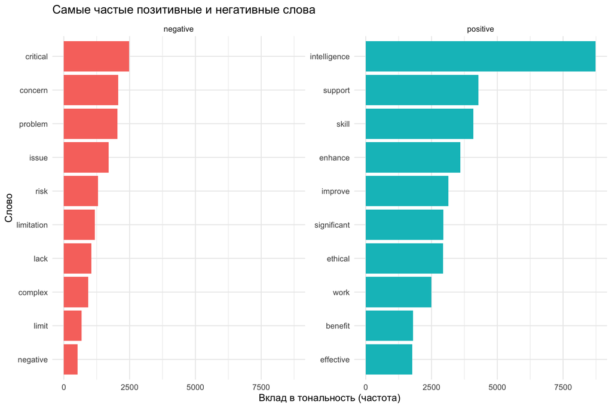

```r
top_sentiment_words %>%
  mutate(word = reorder_within(word, n, sentiment)) %>%
  ggplot(aes(n, word, fill = sentiment)) +
  geom_col(show.legend = FALSE) +
  scale_y_reordered() +
  facet_wrap(~sentiment, scales = "free_y") +
  labs(x = "Вклад в тональность (частота)", y = "Слово",
       title = "Самые частые позитивные и негативные слова") +
  theme_minimal(base_size = 14)
```